# 2016 Presidential Campaign Finance by Megan O’Neil

I am analyzing presidential campaign finance for the 2016 election. I am interested in looking at contributions from around the US.

The ‘us’ datafile contains all campaign contributions in the US for the 2016 presidential election. It contains 7,344,719 observations/pieces of data. I’m going to run my analysis on a sample of 10,000 observations.

```
## 'data.frame':    7344719 obs. of  18 variables:
##  $ cmte_id          : Factor w/ 26 levels "C00458844","C00496034",..: 1 1 1 1 1 1 1 1 1 1 ...
##  $ cand_id          : Factor w/ 25 levels "P00003392","P20002671",..: 11 11 11 11 11 11 11 11 11 11 ...
##  $ cand_nm          : Factor w/ 25 levels "Bush, Jeb","Carson, Benjamin S.",..: 19 19 19 19 19 19 19 19 19 19 ...
##  $ contbr_nm        : Factor w/ 1352948 levels "'CALL, ALLAN",..: 109745 308891 207235 309567 1046542 1046542 522178 207235 998212 522178 ...
##  $ contbr_city      : Factor w/ 25961 levels "","'CALLAHAN",..: 24516 1013 5985 756 756 756 756 5985 756 756 ...
##  $ contbr_st        : Factor w/ 115 levels "20","30","AA",..: 1 2 5 5 5 5 5 5 5 5 ...
##  $ contbr_zip       : Factor w/ 871293 levels "",".","`1136",..: 871228 871232 92700 92660 92444 92444 92444 92700 152 92440 ...
##  $ contbr_employer  : Factor w/ 392185 levels "","''I LIKE COMICS''",..: 328220 230318 99351 101117 366207 366207 167611 99351 141958 286836 ...
##  $ contbr_occupation: Factor w/ 125504 levels "","''''FOR HIRE'''' DRIVER",..: 76234 85057 118479 112965 80842 80842 55604 118479 8049 95139 ...
##  $ contb_receipt_amt: num  175 25 100 500 200 ...
##  $ contb_receipt_dt : Factor w/ 816 levels "01-APR-15","01-APR-16",..: 381 408 508 677 251 200 705 140 460 770 ...
##  $ receipt_desc     : Factor w/ 203 levels ""," SEE REATTRIBUTION",..: 1 1 1 1 1 1 1 1 1 1 ...
##  $ memo_cd          : Factor w/ 2 levels "","X": 1 1 1 1 1 1 1 1 1 1 ...
##  $ memo_text        : Factor w/ 1714 levels ""," SEE REATTRIBUTION",..: 1 989 1 1 1 1 1 1 989 1 ...
##  $ form_tp          : Factor w/ 3 levels "SA17A","SA18",..: 1 1 1 1 1 1 1 1 1 1 ...
##  $ file_num         : int  1082559 1082559 1056862 1029436 1082559 1082559 1029436 1056862 1082559 1047126 ...
##  $ tran_id          : Factor w/ 7194803 levels "A0000FD2A304E432AAD5",..: 3662927 3663652 3571641 4126697 3608114 3605468 4140202 3641793 3663738 4176451 ...
##  $ election_tp      : Factor w/ 10 levels "","G2015","G2016",..: 7 7 7 7 7 7 7 7 7 7 ...
```

```
## 'data.frame':    10000 obs. of  18 variables:
##  $ cmte_id          : Factor w/ 26 levels "C00458844","C00496034",..: 7 8 5 8 7 5 8 7 7 7 ...
##  $ cand_id          : Factor w/ 25 levels "P00003392","P20002671",..: 1 12 10 12 1 10 12 1 1 1 ...
##  $ cand_nm          : Factor w/ 25 levels "Bush, Jeb","Carson, Benjamin S.",..: 4 20 5 20 4 5 20 4 4 4 ...
##  $ contbr_nm        : Factor w/ 1352948 levels "'CALL, ALLAN",..: 338441 1093456 608606 437463 1903 1085227 451435 845869 1105237 808529 ...
##  $ contbr_city      : Factor w/ 25961 levels "","'CALLAHAN",..: 16793 20047 5373 17006 2787 4748 1247 2969 3190 24516 ...
##  $ contbr_st        : Factor w/ 115 levels "20","30","AA",..: 47 59 101 31 81 34 55 110 20 24 ...
##  $ contbr_zip       : Factor w/ 871293 levels "",".","`1136",..: 515437 505816 551154 313892 179801 287714 224857 851857 736431 198552 ...
##  $ contbr_employer  : Factor w/ 392185 levels "","''I LIKE COMICS''",..: 286836 40856 180635 243294 286836 379953 229068 41145 87646 94647 ...
##  $ contbr_occupation: Factor w/ 125504 levels "","''''FOR HIRE'''' DRIVER",..: 112965 98027 8049 73089 858 64615 6776 103579 96288 4179 ...
##  $ contb_receipt_amt: num  59.4 27 2700 15 50 ...
##  $ contb_receipt_dt : Factor w/ 816 levels "01-APR-15","01-APR-16",..: 664 451 451 338 27 9 134 688 485 496 ...
##  $ receipt_desc     : Factor w/ 203 levels ""," SEE REATTRIBUTION",..: 1 1 145 1 1 1 1 1 1 1 ...
##  $ memo_cd          : Factor w/ 2 levels "","X": 2 1 2 1 2 1 1 1 2 1 ...
##  $ memo_text        : Factor w/ 1714 levels ""," SEE REATTRIBUTION",..: 465 324 1185 324 465 1 324 1 613 1 ...
##  $ form_tp          : Factor w/ 3 levels "SA17A","SA18",..: 2 1 1 1 2 1 1 1 1 1 ...
##  $ file_num         : int  1112134 1077916 1071498 1079445 1112134 1071498 1079445 1133832 1126762 1119042 ...
##  $ tran_id          : Factor w/ 7194803 levels "A0000FD2A304E432AAD5",..: 653784 5680515 3747681 6498691 583455 3785103 6381171 1249000 3221321 993345 ...
##  $ election_tp      : Factor w/ 10 levels "","G2015","G2016",..: 3 7 3 7 3 7 7 3 7 3 ...
```

# Univariate Plots Section

## Contribution amount

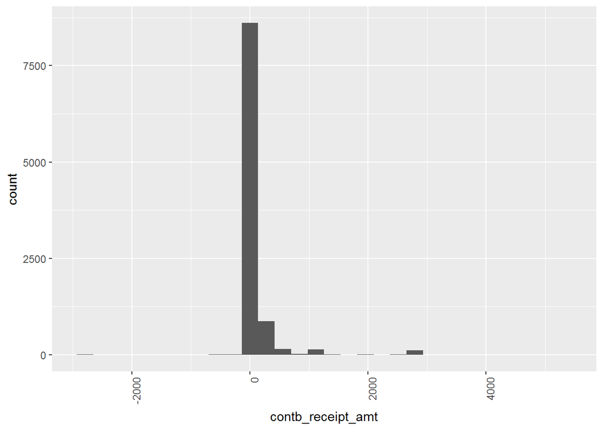

There are negative contributions, I am going to look at these, then remove them from a clean dataset.

```
##    Min. 1st Qu.  Median    Mean 3rd Qu.    Max.
## -2700.0    15.0    27.0   113.9    91.0  5400.0
```

```
##    Min. 1st Qu.  Median    Mean 3rd Qu.    Max.
## -2700.0  -500.0  -100.0  -517.6   -25.0    -5.0
```

```
## [1] 98
```

```
##    Min. 1st Qu.  Median    Mean 3rd Qu.    Max.
##    0.44   16.00   28.00  120.10  100.00 5400.00
```

After removing those negatives, the median contribution amount is $28, mean of $120 and max of $5400. That max is interesting since the maximum allowed for an individual to make to a candidate is $2,700 (source: http://www.fec.gov/info/contriblimitschart1516.pdf). I’m going to look at these a bit more.

There are 3 contributions for $5400, one for $5k, one for $4k, and a number for $2700 in this sample. I am going to leave them, apparently these folks got a workaround for the limit…

Now I’ll look at the distribution of this ‘cleaner’ dataset, without the negative contributions but including the high ones.

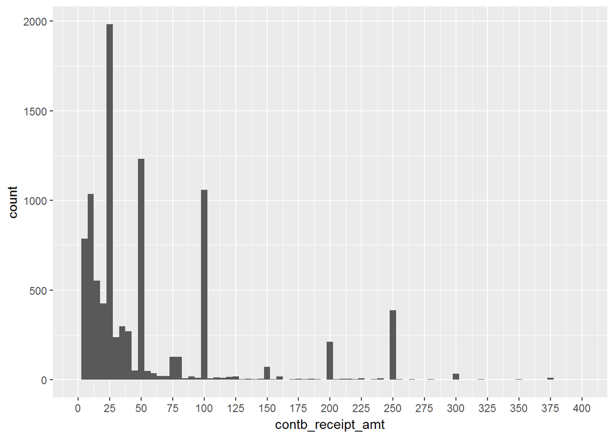

The distribution of contribution amounts is positively skewed. Let’s try a log-10 transformation of the contribution amount.

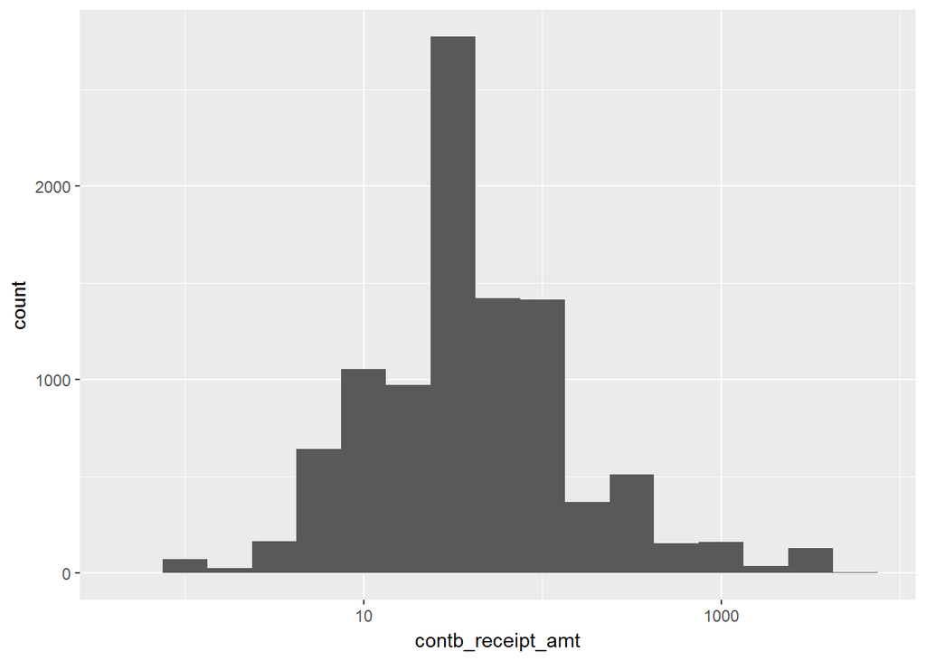

This transformation revealed a much more normal distribution.

### Candidate

Let’s review by candidate.

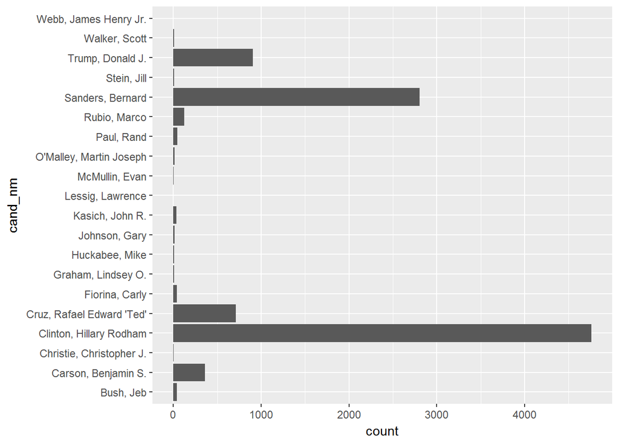

Clinton had the largest number of donations, follwed by Sanders, Trump, then Cruz.

Let’s look at the primaries only. I’m going to proxy the primaries by including up to the date that Sanders officially dropped out of the race, whch was on July 11th, 2016 according to CNN. (CNN: http://www.cnn.com/2016/07/11/politics/hillary-clinton-bernie-sanders/)

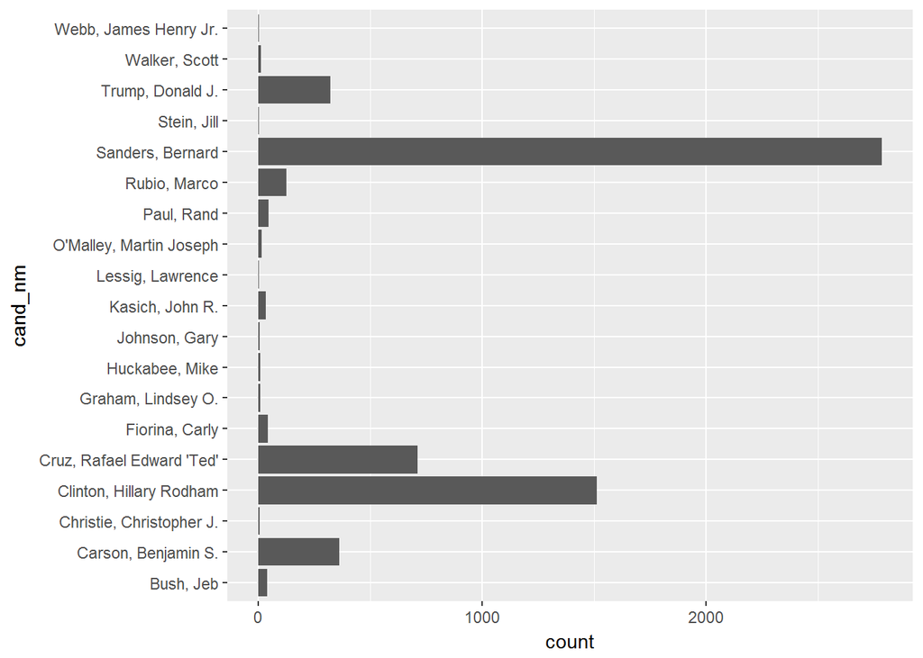

In the primaries, Sanders is ahead of Clinton by a landslide.

## Political party

I want to add political party, which I think may have an effect on contribution size.

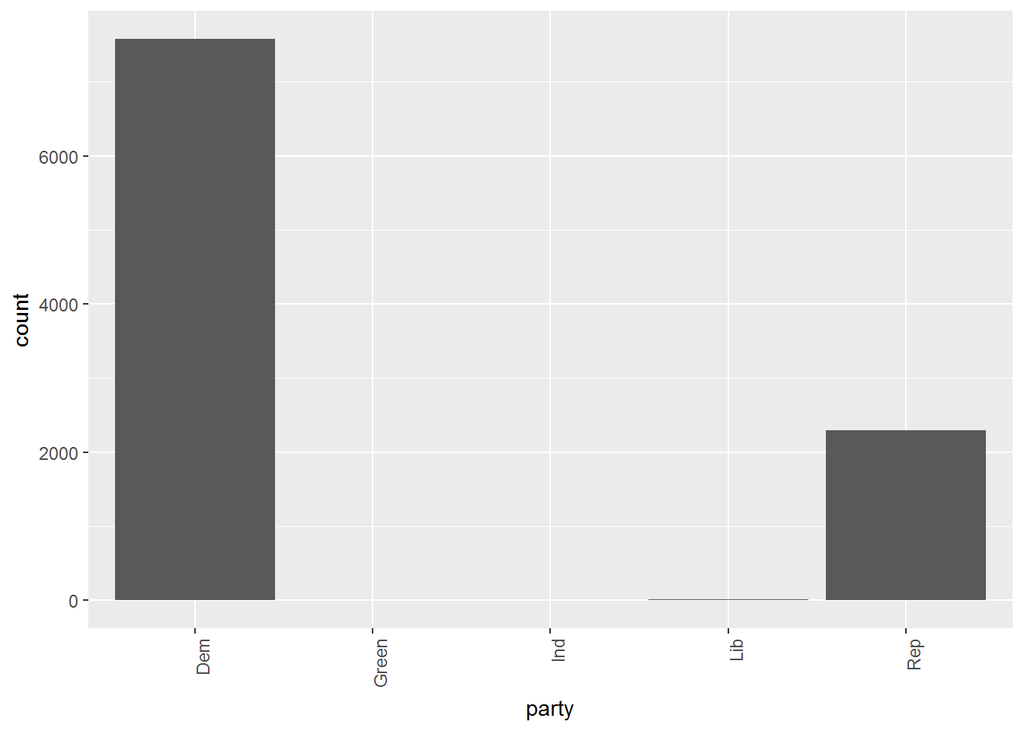

Here is the count of contributions by political party. The democrats received by far the most campaign contributions, more than double that of Republicans. (Actual counts here are not meaningful as this is a sample.) The numbers of contributions to the other party categories, Green, Libertarian, and Independent, are negligible in comparison.

I will try a transformation of counts to see if we can view the other parties a little more clearly.

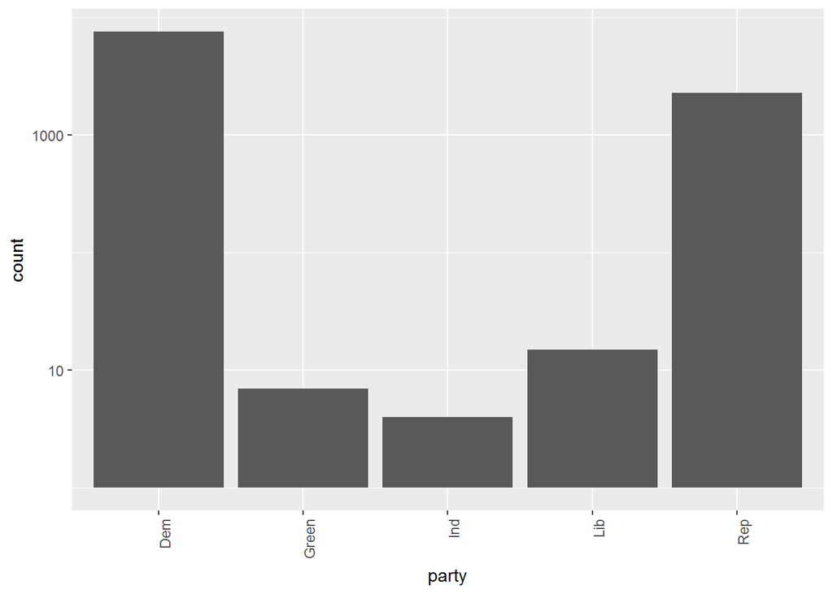

With the log10 transformation of counts, we can see the other parties more clearly. Within the smaller parties, Libertarians had the highest count of contributions, followed by Green, followed by Independent. There was only one candidate in this sample for each of those parties: Jill Stein (Green), Evan McMullin (Independent), and Gary Johnson (Libertarian). Note that Jim Webb’s official party is Independent, but he ran in Democratic primaries so I’ve included him as a Democrat.

## State

I am interested in both the contributions by state and also contributions per capita by state. As such I’ll want to add in state population at some point, so I’ll do that now. I also noticed there are some weird state abbreviations in here, so I’ll take a look and remove the weird ones.

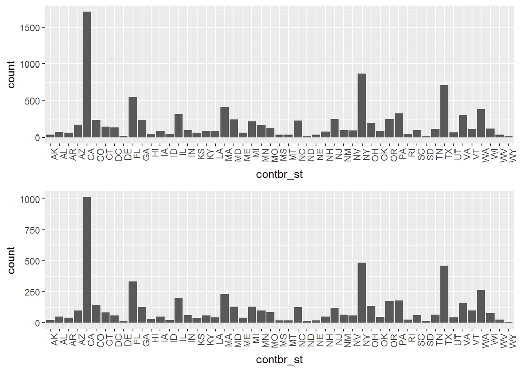

The top plot shows the count of contributions by state for the full election cycle; the bottom plot shows only the primaries.

In both plots, states with the highest contributions were California, New York, and Texas. Those are also the states with the highest population, so I will be interested to look at per capita rates of giving for each state. But that’s later on when I transform the datasets.

There is not much if any discernible difference in the distribution of contributions among states between the primaries and the overall election cycle, other than the actual count of contributions. Makes sense.

## Occupation

```
## [1] 2397
```

At over 2,000 unique occupations, that’s too many to plot! I have enough to look at otherwise.

## Contribution date

```
##         Min.      1st Qu.       Median         Mean      3rd Qu.
## "2014-12-23" "2016-03-01" "2016-05-24" "2016-05-17" "2016-08-31"
##         Max.
## "2016-11-21"
```

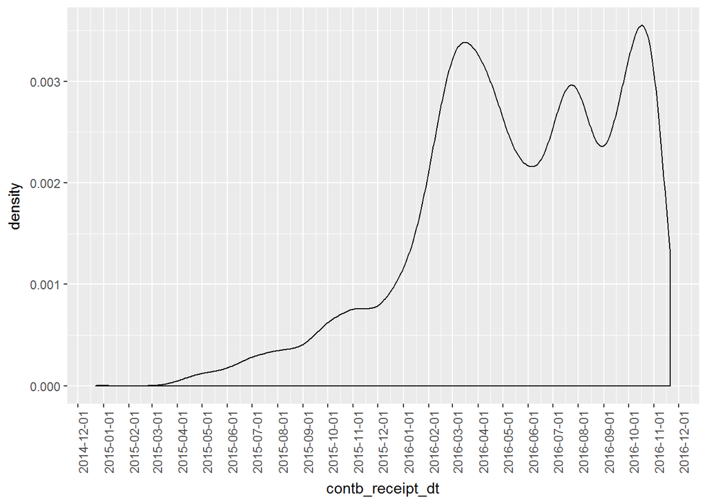

# Univariate Analysis

### What is the structure of your dataset?

In the full US dataset, there are 7,344,719 contributions. I am interested in looking at the distribution of contributions across all 50 states, but realize the limitations of my computer in working with such a large dataset. So I took a sample of 10,000 contributions, ‘us_samp’.

The dataset has 18 variables: * 15 factor variables (none are ordered): cmte_id, cand_id, cand_nm, contrb_nm, contbr_city, contbr_st, contbr_zip, contbr_employer, contbr_occupation, receipt_desc, memo_cd, memo_text, form_tp, file_num, tran_id, election_tp. * 1 date variable: contb_receipt_dt (this was originally a factor variable but I converted it) * 1 integer: file_num * 1 number: contb_receipt_amt

### What is/are the main feature(s) of interest in your dataset?

I am most interested in the variables pertaining to candidate name and contribution receipt amount. I am interested in viewing the number and size of contributions that candidates received.

### What other features in the dataset do you think will help support your investigation into your feature(s) of interest?

Other factors that contribute to the number and size of contributions to each candidate include: * contributor’s state * contribution receipt date * candidate’s political party

### Did you create any new variables from existing variables in the dataset?

I created two variables: * party - for the political party of the candidate. * population - for the state population in 2015, in order to determine contributions per capita by state.

### Of the features you investigated, were there any unusual distributions? Did you perform any operations on the data to tidy, adjust, or change the form of the data? If so, why did you do this?

I log transformed the right skewed contribution amount distributions. The transformed distribution appears more normal, peaking at around $30.

I also used a log 10 transformation on the counts of contributions by political party, since there was a huge difference between Democrats and Republicans, as compared to Green, Independent, and Libertarian parties.

The contribution date was the only other non-categorical variable, but I did not perform a transformation because these are dates, not numerical values, so a log or square transformation, are not appropriate.

# Bivariate & Multivariate Plots Section

I wanted to start with ggpairs to plot every variable against each other. I would have liked to use ggpairs but this analysis is challenging because all but 3 variables are categorical with more than 15 factors, which is the limit for ggpairs.

I’ve combined bivariate and multivariate because once I start looking at relationships between variables, it is easy and helpful to add additional variables in to review.

## Donations over time, lines for each party

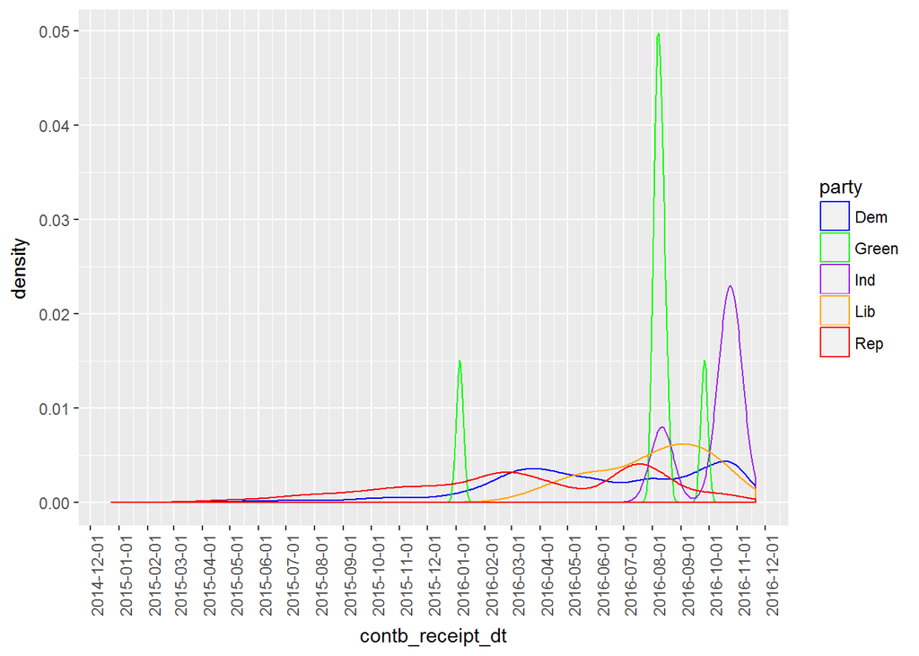

This density plot is interesting becuase it shows relative density of contributions by each party. The Green party has a much more distinct line because there were far fewer contributions overall than for the Republican and Democratic party, so the density plot is affected by one or two donations in this sample.

Now I want to demonstrate total contributions over time for each party (rather than density of contributions), with lines included for when the second-to-last candidate in the Republican and Democratic primaries dropped out (Cruz and Sanders respectively). Given the small number of contributions for Green, Libertarian, and Independent parties (just 23), let’s just use Democrats and Republicans.

```
## [1] 23
```

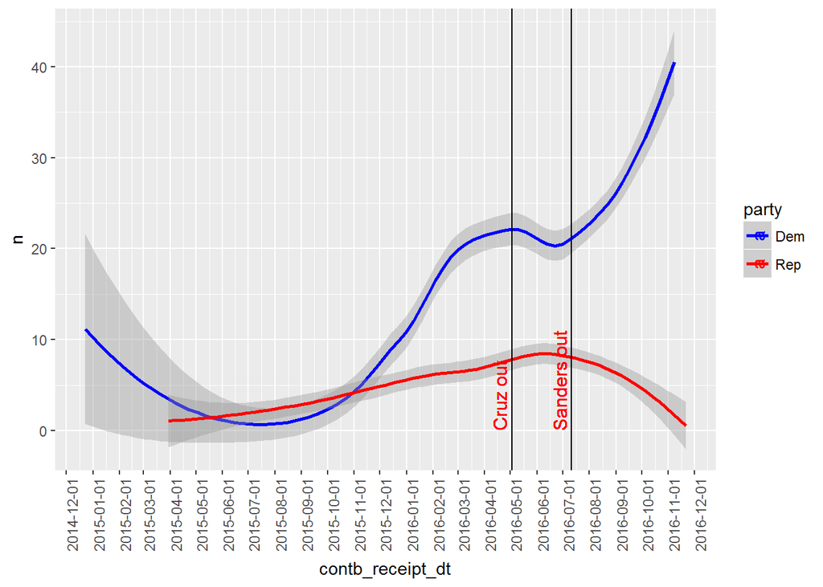

I like this plot, showing a ‘smoothed’ line for the number of contributions received over time by candidates in the Democratic and Republican parties. I added lines to show when the last non-successful primary candidate dropped out - Cruz for Republicans and Sanders for Democrats.

It is interesting that the ‘Cruz out’ line crosses more of an inflection point for Democrats than does the ‘Sanders’ out line. I expected more of an inflection for the party line based on their respective last candidate drop out date.

Let’s look at contributions to each candidate for top 4 candidates.

## Top Candidates contributions over time

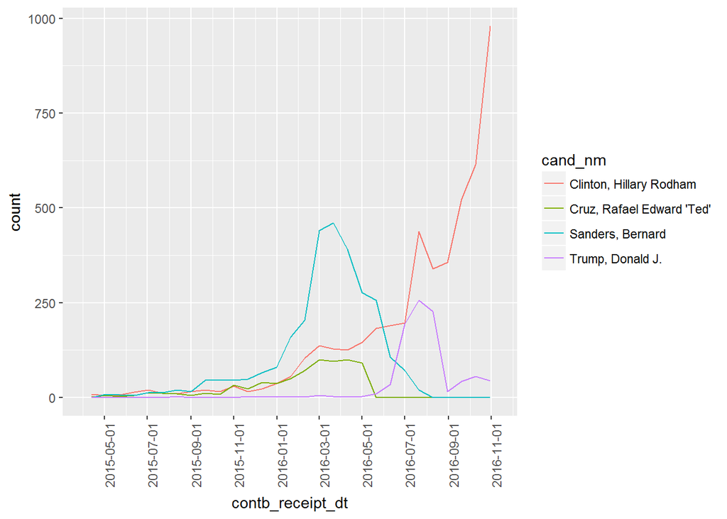

I’ve switched to a frequency polygon plot to show the actual numbers of contributions by candidate over time, rather than a smoother line with the total number of donations on each date for each candidate, as I did with the party plot above. The frequency polygon is both more accurate and easier to interpret since the smoother line showed negative contribution amounts for some candidates.

This shows an interesting difference in the shape of each candidate’s line. The primary candidates peak earlier, with Sanders reaching a much higher peak than anyone else in the primary season, around mid-March. Trump and Clinton both jump to their peaks after the primaries are over, though Clinton keeps soaring as Trump falls again before the election.

## Top candidates average donation size over time

Let’s see how average donation size varied over time for these candidates.

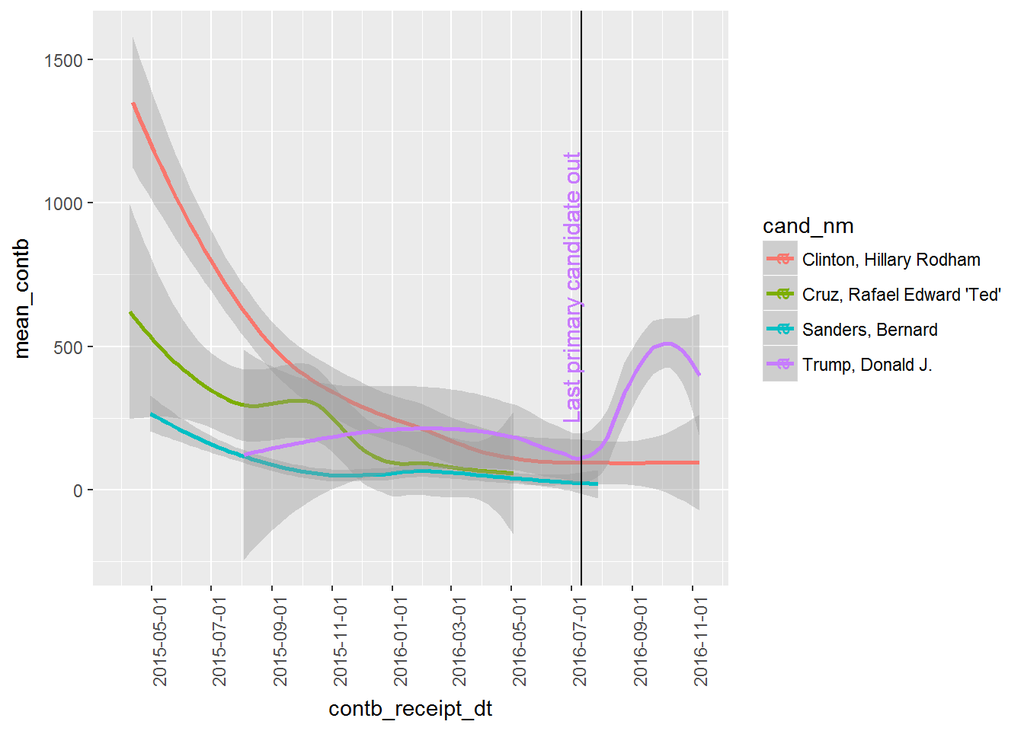

I like this plot, too. Clinton started off with some giant donations. Really interesting to see Trump’s mean contribution amount jump quite significantly once it was officially Clinton v. Trump from the major parties.

## Contributions by state

I want to look at number and size of contributions by state.

```
## [1] 0.1184116
```

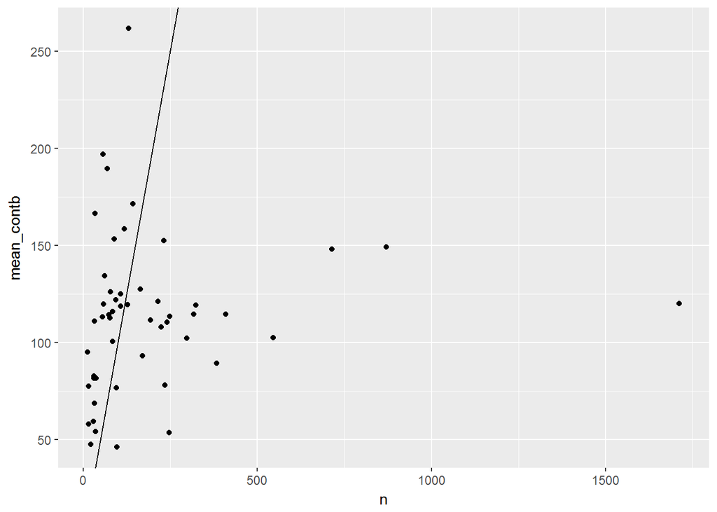

This last plot is somewhat interesting, but not really. There’s a weak positive correlation (0.11) between the number of contributions and the average size of donations in states. So very roughly, as more people contribute, the average contribution size goes up. This plot is most clustered around about 100 people giving in a state, at an average of about $120. That’s actually fairly high. Remembering that this is a sample, we can’t actually look at the number of contributions as meaningful, only the trends.

Let’s create a heat map of the US with average contribution sizes in bins by color.

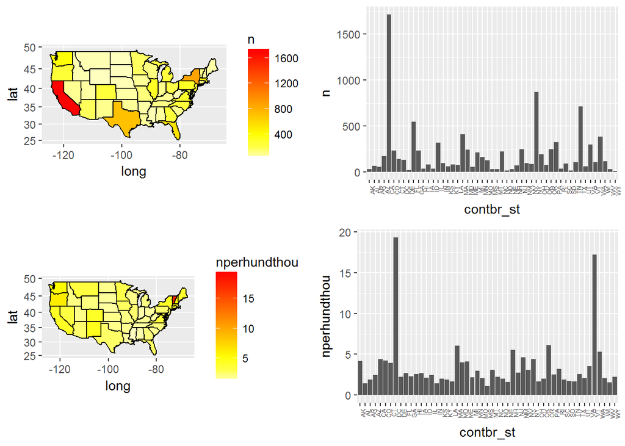

Here are heat maps of the US, along with their corresponding bar charts. The size of the bar charts makes them pretty impossible to read state names, but interesting to see a bar chart reflection of the heat map.

The top map and chart are of total contributions per state, again showing hot spots of California, then NY and Texas.

The bottom map and chart show contributions per hundred thousand residents. Vermont and DC 9which is too small to see on the map) are so high, that the other states are all light yellow, less useful of a map.

Here are maps of mean contributions per state.

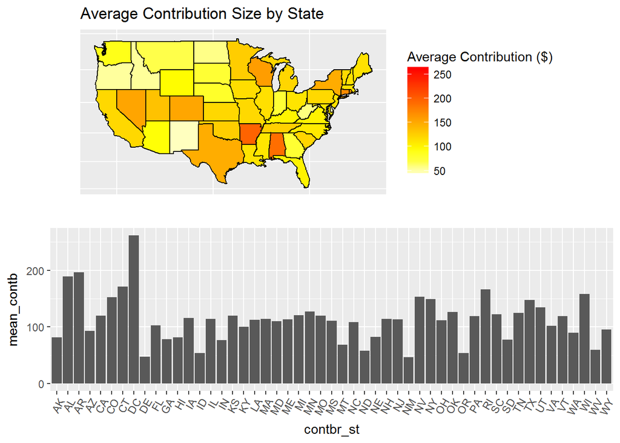

## State by candidate

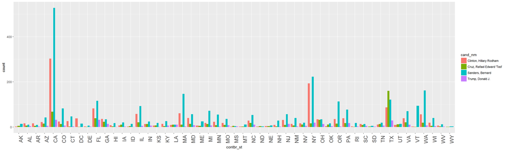

The democratic candidates appear to be clearly above Republicans in most sates, notably excepting Texas in which Cruz is leading. Sanders appears to be beating Hilary in contributions in almost every state. Let’s look at just the two of them.

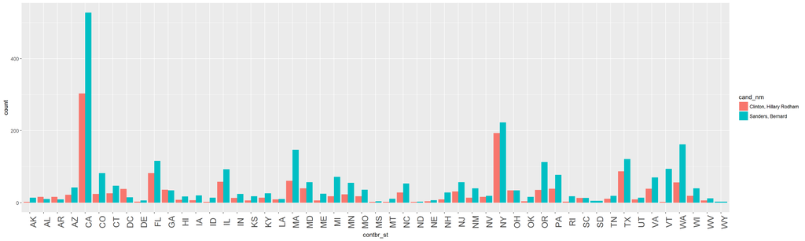

Yes, looks like Sanders was ahead in number of contributions in almost every state.

How about just among republicans

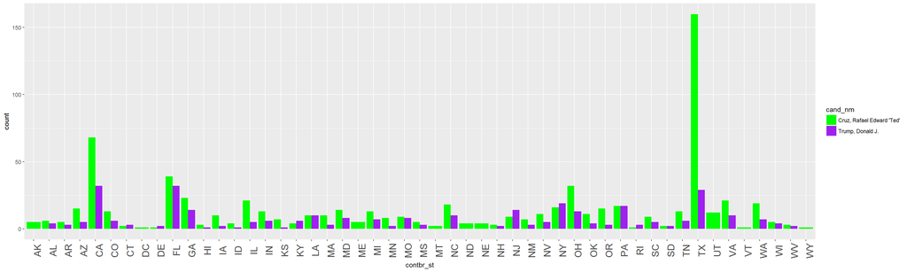

With just a couple of exceptions - it looks like Cruz had more contributions than Trump in almost every state.

Let’s see this in a slightly different way - through ratios.

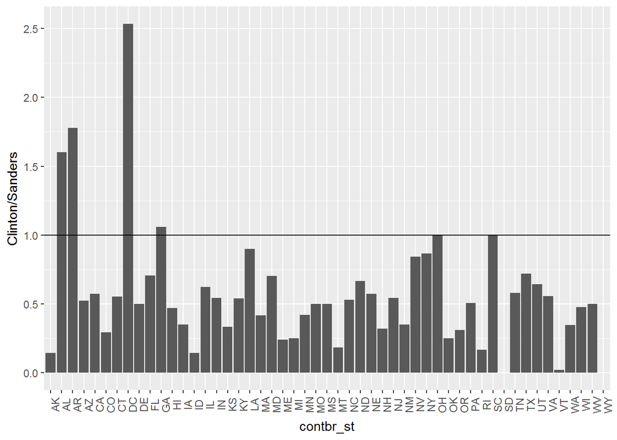

This plot shows the ratio of number of contributions between Clinton and Sanders. States below horizontal line indicate Sanders had more contributors than Clinton; above 1 Clinton won. So in 2 states they tied (Ohio and South Carolina), in 4 states Clinton had more than Sanders (Alabama, Arkansas, and DC-not actually a state), there were 0 contributions from South Dakota in this sample, and in the remaining 44 states, Sanders beat clinton.

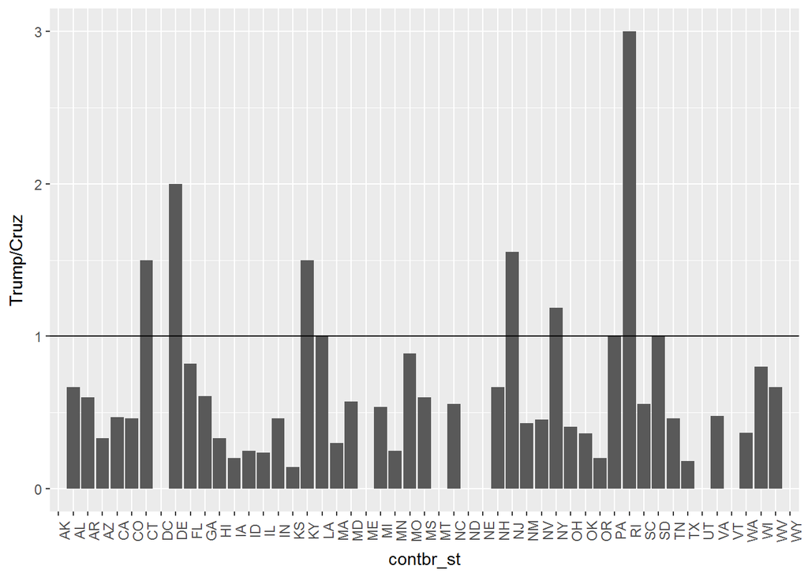

This one shows the ratio of number of contributions between Trump and Cruz. States below horizontal line indicate Cruz had more contributors than Trump; above mean Trump had more. Again, Cruz appeared to have more contributions in more states than Trump, though less decisively than Sanders.

## Size by candidate by party

I’m curious to see a box and whisker plot for campaign contribution size by candidate, colored by political party.

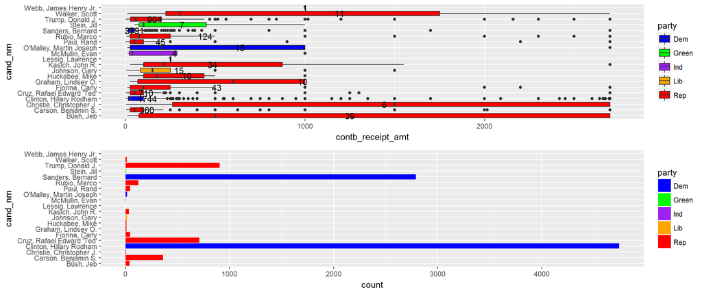

It’s a little hard to see, but this set of plots demonstrates that broadly, those with the most contributions also had lower averages. Makes sense. Those who dropped out earlier had higher medians, with much higher variance, because there were fewer giving.

I cut contribution amounts above 2750 to reduce outliers. But as we can in the distribution of contribution amounts within certain candidates, there remain a lot of outliers, like for Clinton.

I want to do it for just Sanders, Clinton, Trump, and Cruz during the primaries.

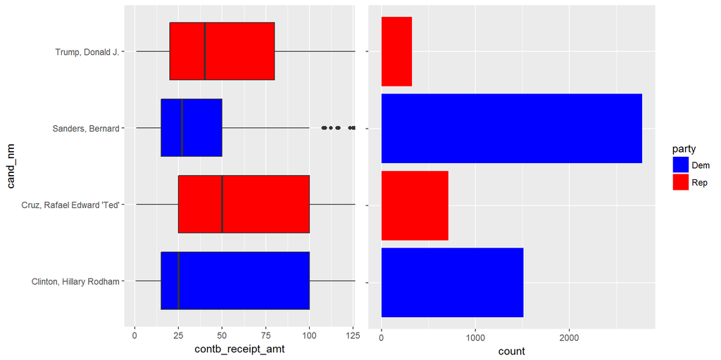

The two democratic candidates, Clinton and Sanders are very close with median contributions of $25 and $27 respectively; with higher median contributions for republican candidates at $40 for Trump and $50 for Cruz.

As shown in the plot to the right, in both parties, the candidates with the most contributions did not win the primary.

Let’s check the mean and median contributions of each candidate in table form:

```
## # A tibble: 4 × 4
##                     cand_nm mean_contb median_contb     n
##                      <fctr>      <dbl>        <dbl> <int>
## 1   Clinton, Hillary Rodham  176.59549           25  1509
## 2 Cruz, Rafael Edward 'Ted'  114.22149           50   710
## 3          Sanders, Bernard   50.46301           27  2773
## 4          Trump, Donald J.  120.19009           40   322
```

As shown, the mean contribution varied more substantially - with Clinton at the high point of over $176; Sanders at low of $50, and Trump and Cruz int he middle at $120 and $114 respectively. Clearly there are outliers for all candidates which drag the means higher than the medians.

# Multivariate Analysis

### Talk about some of the relationships you observed in this part of the investigation. Were there features that strengthened each other in terms of looking at your feature(s) of interest?

I looked at the number and size of contributions to each candidate over time, by party, and by state.

I ended up focusing charts on the top 4 candidates, because the other candidates often did not have enough data to draw meaningful observations from the sample.

I enjoyed making map visualiziations of the data, but this was not as useful to look at my primary interest of viewing the difference in contribution amount and size between candidates.

### Were there any interesting or surprising interactions between features?

I was somewhat surprised by the very distinct paths of contribution size to each candidate over time. As Clinton’s support went from large contributions to many small; Trump’s went from few small size then made a jump to larger contributions once the primaries were over.

It was also interesting to view in boxplot form how Democrats rely on numerous smaller donations, and Republicans get more big dollar donors. While the mean contribution size was not that distinct, it was different, and the number of contributions for the top two democratic candidates far exceeded the number of contributions for the top two republican candidates.

# Final Plots and Summary

### Plot One

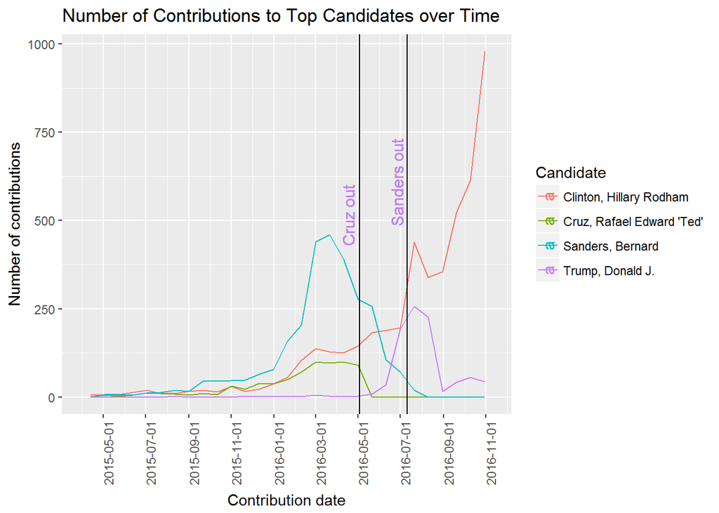

### Description One

The candidates that continued (Clinton and Trump) had a peak to date in mid-July, around the time of both parties’ national conventions. After this point, the number of contributions to Trump, the candidate who ultimately won, fell quite dramatically, while the number of contributions to Clinton initially fell, then peaked, at over two times the amount of the peak in July.

Note that the actual number of contributions demonstrated in this chart reflects a sample of total overall contributions.

### Plot Two

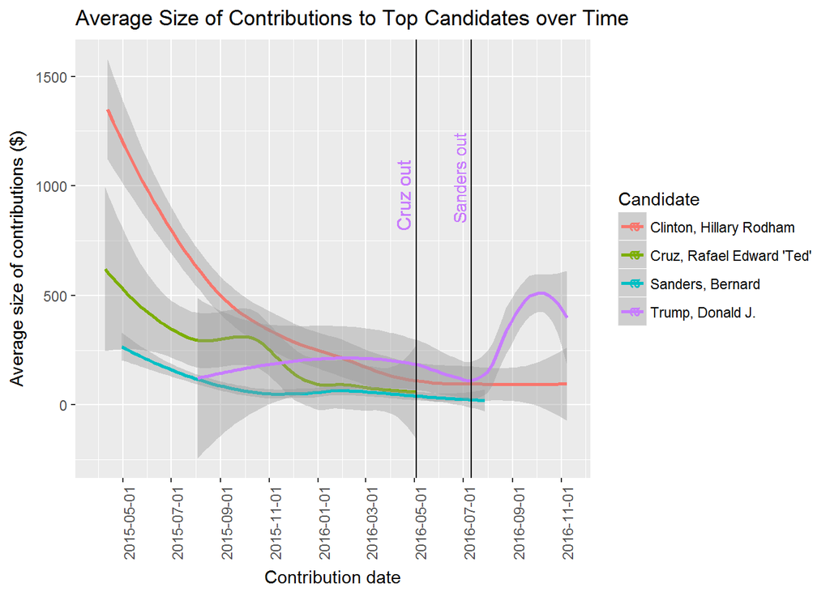

### Description Two

The average contribution size over time followed a similar pattern for Clinton, Sanders, and Cruz; with higher average amounts at the start of the race. This was much more pronouned for Clinton, whose initial average contribution size was over $1200, compared to Sanders whose initial average contribution size was around $250. While Cruz had a jump around October2015, these three candidates generally had their average donation size fall througout the course of the campaign.

Trump, on the other hand, a notably unconventional candidate, started receiving contributions late, with his average contribution size at about the lowest it was throughout the race. His average size increased dramatically when the race dropped to just Trump and clinton.

### Plot Three

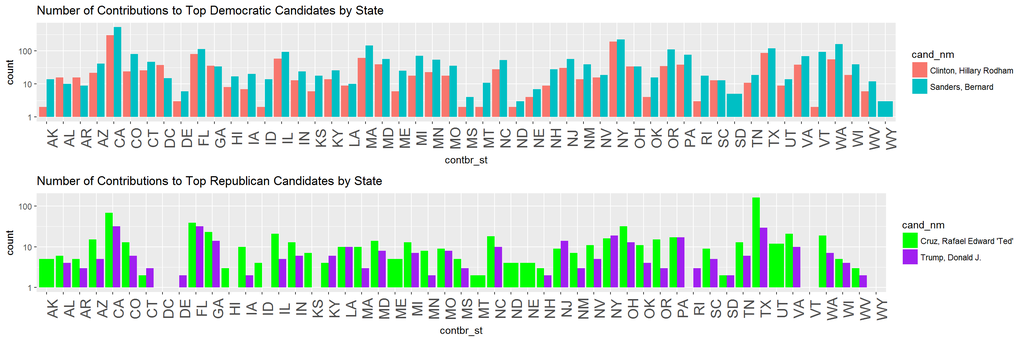

### Description Three

These charts compare the number of contributions to each candidate by state, with the top chart showing Clinton and Sanders; the bottom chart showing Trump and Cruz. As demonstrated, in most states for both party, the candidate who ultimately dropped out of the race received more contributions.

The y axis with count of contributions has the application of a log10 transformation to more clearly show the difference between candidates for all states.

# Reflection

## Where did I run into difficulties in the analysis?

In general, I ran into difficulties assessing the best methods to assess the data, and what subsets to use to do so. I was very interested in looking at a sample of the entire country, rather than simply one state. This required a sample, which cauesd some limitations in my analysis. For example, there were only a handful of contributions to candidates from parties that weren’t Democratic or Republican, which made it difficult to draw conculsions on average sample size or trends in dates of contributions.

So I decided to subset the data to the four top candidates. I also decided that I should further subset the data in some cases to the primaries, so that I could draw a relatively more even comparison between the number of contributions for candidates, since using the full dataset favored the candidates who went on to the general election and continued collecting contributions.

Ensuring throughout that my subsetting was working appropriately was surprisingly challenging, but instilled some better practices in naming data subsets.

## Where did I find successes?

I found sucess in assessing how contributions–numbers as well as mean/median size– changed over time using the date. After converting the contriubtion receipt date to a date object, this was a very valuable variable in assesing trends over time. I think the most fascinating aspect was how different Trump’s contribution distribution over time varied from the other top candidates, as demonstrated in plots 1 and 2 above in the final plots section.

## How could the analysis be enriched in future work (e.g. additional data and analyses)?

I think it would be fascinating to see over different election cycles how these trends play out. Most in the US see Trump as an extremely unusual candidate, who won in spite of incredible odds against him (according to most analysts). In this election, the andidates from both major parties that went on to the general election had far fewer contributions than their runner-ups, a trend that was present in the majority of states. I would be curious how common this is.

I am also curious over time if Republicans have always had higher contribution sizes and fewer contributions than democrats. If that has been present for recent history and if the difference is increasing or decreasing.